# Analysis of Weight Lifting Exercise Dataset

## Importing the data

```r
# Load in the data with headers
rawTraining <- read.csv("pml-training.csv",header=T)
rawTesting <- read.csv("pml-testing.csv",header=T)
```

## Exploring the Data

I began with a quick look through the column information.

### User Name

A quick glance through the user_name column reveals that the test was taken from 6 subjects:

```r
users <- levels(rawTraining$user_name)

print(users)
```

```
## [1] "adelmo"   "carlitos" "charles"  "eurico"   "jeremy"   "pedro"
```

### Sensor Array Locations

Looking through the column data, we find that each user had 4 sensors attached to them as they lifted weights. These sensors were located at the:

- belt
- arm
- dumbbell
- forearm

### Sensors

At each sensor location, there is a Gyroscope, an Accelerometer, and a Magnetometer. Each one of these sensors has information on the x, y and z direction. That that means that all three of these are readings in the carteasian coordinate system. These columns are labeled:

- gyros*(loc)*(dir)
- accel*(loc)*(dir)
- magnet*(loc)*(dir)

### Angles

Additionally, the columns also include roll, pitch, and yaw information. That means that all three of these are in the polar coordinate system. It is more than likely that these columns were in fact derived from the gyro/accel/magnet information. However, it is not immediately clear what the methodology was for conversion (e.g. it could have been a mix of multiple sensors or only one). Ether way, I will assume the data to be already processed in some way:

- roll_(loc)
- pitch_(loc)
- yaw_(loc)

### Classe

The column we are ultimately trying to predict is the classe column. Based on what we know of the problem, this corresponds to the manner in which the users are lifting weights. We can see that there are five different ways that the users were asked to lift the weights:

```r
levels(rawTraining$classe)
```

```
## [1] "A" "B" "C" "D" "E"
```

### Other Columns

There are several other columns present in the dataset, however, they are mostly NAs. To keep things simple, I will focus on the ones we have here.

### Collecting Columns

Let's collect the variables we will use for prediction:

```r
locations <- c("belt","arm","dumbbell","forearm")
sensors <- c("gyros","accel","magnet")
directions <- c("x","y","z")
angles <- c("roll","pitch","yaw")


# Every combination of locations, sensors, and directions
xyzCols <- sort( apply( X = expand.grid(sensors,locations,directions) , MARGIN = 1, FUN = function(s) paste(s,collapse="_") ) )

# Every combination of locations and angles
rpyCols <- sort( apply( X = expand.grid(angles,locations) , MARGIN = 1, FUN = function(s) paste(s,collapse="_") ) )

xCols <- c("user_name",xyzCols,rpyCols)

print(xCols)
```

```
##  [1] "user_name"         "accel_arm_x"       "accel_arm_y"
##  [4] "accel_arm_z"       "accel_belt_x"      "accel_belt_y"
##  [7] "accel_belt_z"      "accel_dumbbell_x"  "accel_dumbbell_y"
## [10] "accel_dumbbell_z"  "accel_forearm_x"   "accel_forearm_y"
## [13] "accel_forearm_z"   "gyros_arm_x"       "gyros_arm_y"
## [16] "gyros_arm_z"       "gyros_belt_x"      "gyros_belt_y"
## [19] "gyros_belt_z"      "gyros_dumbbell_x"  "gyros_dumbbell_y"
## [22] "gyros_dumbbell_z"  "gyros_forearm_x"   "gyros_forearm_y"
## [25] "gyros_forearm_z"   "magnet_arm_x"      "magnet_arm_y"
## [28] "magnet_arm_z"      "magnet_belt_x"     "magnet_belt_y"
## [31] "magnet_belt_z"     "magnet_dumbbell_x" "magnet_dumbbell_y"
## [34] "magnet_dumbbell_z" "magnet_forearm_x"  "magnet_forearm_y"
## [37] "magnet_forearm_z"  "pitch_arm"         "pitch_belt"
## [40] "pitch_dumbbell"    "pitch_forearm"     "roll_arm"
## [43] "roll_belt"         "roll_dumbbell"     "roll_forearm"
## [46] "yaw_arm"           "yaw_belt"          "yaw_dumbbell"
## [49] "yaw_forearm"
```

And the one column we will be predicting

```r
yCol <- "classe"
```

## Exploring the Data

To get a feel for the data, lets plot the interaction of the belt x accelerometer and the user name. To plot, I will be using ggplot2.

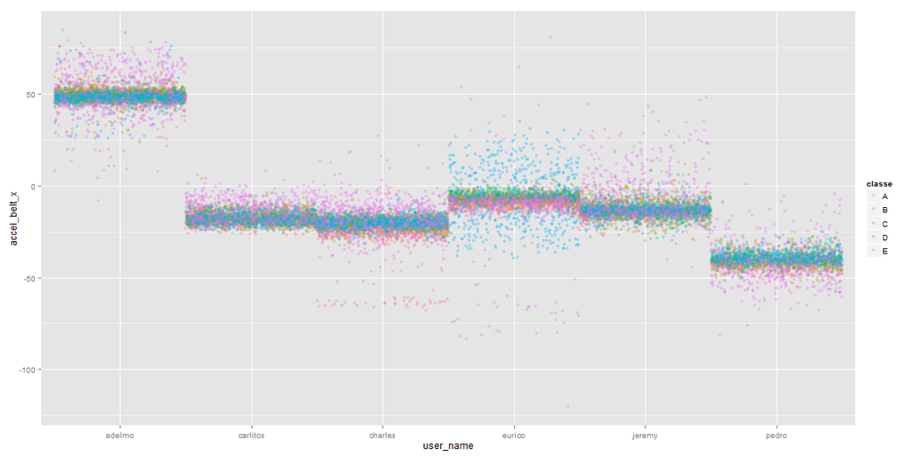

```r
library(ggplot2)

ggplot(rawTraining,aes(x=user_name,y=accel_belt_x,color=classe)) + geom_point(position=position_jitter(width=.5),alpha=.3)
```

The main thing to notice about this is that the data is centered around different points for different users. After a quick check of the other columns, I found this to be true of them as well. Each user may have had the sensor array positioned slightly differently on their bodies wich could have been the reason for the different centers. One idea I had was to manually center these predictors for each user separately as sort of a calibration of the sensors. I will test this idea later.

## Splitting the Data

Now that we have an idea of where we are going, lets split our training data into two sets so we will have some way of judging the out of sample error.

```r
library(caret)
# Create a partition
set.seed(12345)
inTrain <- createDataPartition(y=rawTraining$classe,p=0.75,list=F)

# Divide the data using the partition
train <- rawTraining[inTrain,c(xCols,yCol)] # For training
testOOSE <- rawTraining[-inTrain,c(xCols,yCol)] # For checking out of sample error
testPROJ <- rawTesting[,xCols] # The project test set

# Display the dimensions
dim(train)
```

```
## [1] 14718    50
```

```r
dim(testOOSE)
```

```
## [1] 4904   50
```

```r
dim(testPROJ)
```

```
## [1] 20 49
```

## Centering the data

As was discussed earlier, we will want to center the data for each of the columns and people separately. To do this I will take advantage of the plyr package (for ddply and join):

```r
library(plyr)

# The new column names
meanNames <- paste("MEAN",xCols[-1],sep="_")
adjNames <- paste("ADJ",xCols[-1],sep="_")

# Calculate the column mean
colMeans<-ddply(train[,xCols],.(user_name),numcolwise(mean))
names(colMeans)<-c("user_name",meanNames)

# Create a fubctuib to perform the centering
centerFun <- function(df){
  # Add the column means
  trainADJ <- join(df,colMeans,"user_name","left","first")

  # Subtract out the means
  trainADJ[,adjNames] <- trainADJ[,xCols[-1]] - trainADJ[,meanNames]

  return(trainADJ)
}

# Center the datasets
trainADJ <- centerFun(train)
testOOSEADJ <- centerFun(testOOSE)
testPROJADJ <- centerFun(testPROJ)
```

To sanity check the code, I will redo the plot from earlier on the adjusted training dataset. Note that a few of the data points will be missing when compared to the original plot because we partitioned the dataset

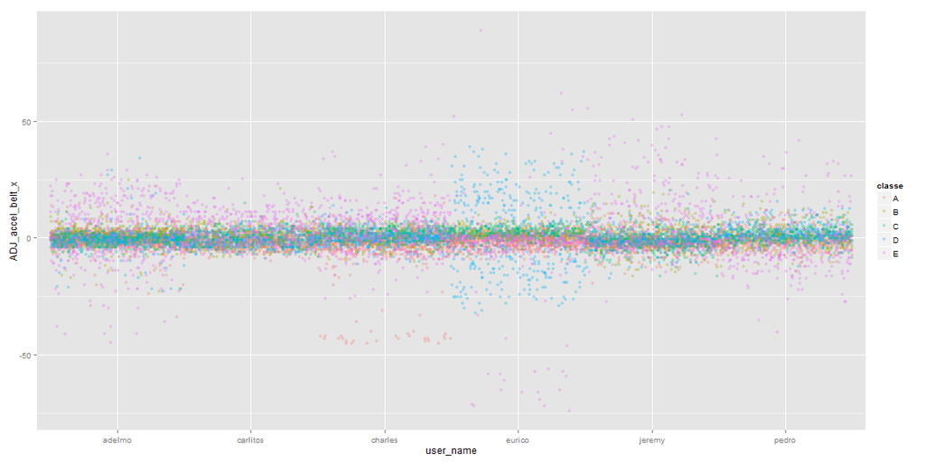

```r
ggplot(trainADJ,aes(x=user_name,y=ADJ_accel_belt_x,color=classe)) + geom_point(position=position_jitter(width=.5),alpha=.3)
```

As you can see the data has been properly centered.

## Traing the Model

For my first attempt at prediction, I will fit a decision tree to the two datasets.

```r
# Without centering
set.seed(122333)
system.time(fitA <- train(classe~.,data=train,method="rpart"))
```

```
##    user  system elapsed
##   95.00    0.53   97.48
```

```r
# With Centering
set.seed(333221)
system.time(fitB <- train(classe~.,data=trainADJ[,c("classe","user_name",adjNames)],method="rpart"))
```

```
##    user  system elapsed
##  119.68    0.36  121.19
```

Lets take a look at the in sample and out of sample errors for both of the predictions.

```r
# Without Centering
predictA <- predict(fitA,train)
confusionMatrix(predictA,train[,"classe"])
```

```
## Confusion Matrix and Statistics
##
##           Reference
## Prediction    A    B    C    D    E
##          A 2569  457   69  141   38
##          B  433 1627  119  334  655
##          C  893  631 2037 1263  621
##          D  281  133  342  674  150
##          E    9    0    0    0 1242
##
## Overall Statistics
##
##                Accuracy : 0.554
##                  95% CI : (0.546, 0.562)
##     No Information Rate : 0.284
##     P-Value [Acc > NIR] : <2e-16
##
##                   Kappa : 0.44
##  Mcnemar's Test P-Value : <2e-16
##
## Statistics by Class:
##
##                      Class: A Class: B Class: C Class: D Class: E
## Sensitivity             0.614    0.571    0.794   0.2794   0.4590
## Specificity             0.933    0.870    0.720   0.9264   0.9993
## Pos Pred Value          0.785    0.514    0.374   0.4266   0.9928
## Neg Pred Value          0.859    0.894    0.943   0.8677   0.8913
## Prevalence              0.284    0.194    0.174   0.1639   0.1839
## Detection Rate          0.175    0.111    0.138   0.0458   0.0844
## Detection Prevalence    0.222    0.215    0.370   0.1074   0.0850
## Balanced Accuracy       0.773    0.721    0.757   0.6029   0.7291
```

```r
# With Centering
predictB <- predict(fitB,trainADJ[,c("classe","user_name",adjNames)])
confusionMatrix(predictB,trainADJ[,"classe"])
```

```
## Confusion Matrix and Statistics
##
##           Reference
## Prediction    A    B    C    D    E
##          A 3668 1287  765  849  262
##          B    0    0    0    0    0
##          C  517 1561 1802 1432  883
##          D    0    0    0    0    0
##          E    0    0    0  131 1561
##
## Overall Statistics
##
##                Accuracy : 0.478
##                  95% CI : (0.47, 0.486)
##     No Information Rate : 0.284
##     P-Value [Acc > NIR] : <2e-16
##
##                   Kappa : 0.325
##  Mcnemar's Test P-Value : NA
##
## Statistics by Class:
##
##                      Class: A Class: B Class: C Class: D Class: E
## Sensitivity             0.876    0.000    0.702    0.000    0.577
## Specificity             0.700    1.000    0.638    1.000    0.989
## Pos Pred Value          0.537      NaN    0.291      NaN    0.923
## Neg Pred Value          0.934    0.806    0.910    0.836    0.912
## Prevalence              0.284    0.194    0.174    0.164    0.184
## Detection Rate          0.249    0.000    0.122    0.000    0.106
## Detection Prevalence    0.464    0.000    0.421    0.000    0.115
## Balanced Accuracy       0.788    0.500    0.670    0.500    0.783
```

## Training Results Exploration

As you can see, neither of these are particularly good. Worse, my theory on centering the datasets actually made the prediction even worse! For some reason, the centering of the data convince it to never guess B or D. Lets explore the decision tree for A to see if there is any way we can improve this.

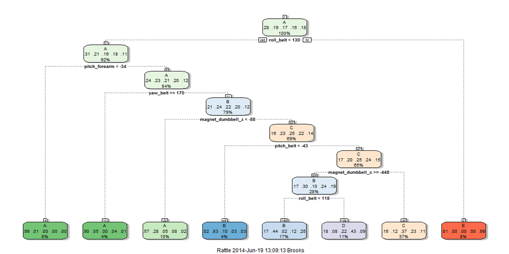

```r
library(rattle)
library(rpart.plot)

fancyRpartPlot(fitA$finalModel)
```

Looking at the predictors we notice a few things. First, we can see that it never once used the user name as a predictor. We also see that it seemed to use the processed predictors (roll, pitch, yaw) more frequently that it used the x,y,z information.

## Roll Pitch Yaw

Because roll, pitch, and yaw are all in degrees, it may be worth while to transform them to something more “natural” or “innate”. Perhaps taking the sin and cos of the roll, pitch, and yaw information may result in something more.

```r
trainSC <- train
trainSC[,paste("SIN",rpyCols,sep="_")] <- sin(train[,rpyCols]*pi/180)
trainSC[,paste("COS",rpyCols,sep="_")] <- cos(train[,rpyCols]*pi/180)
```

```r
# Without centering
set.seed(122333)
system.time(fit2A <- train(classe~.,data=trainSC,method="rpart"))
```

```
##    user  system elapsed
##  141.66    0.62  143.64
```

```r
# Without Centering
predict2A <- predict(fit2A,train)
confusionMatrix(predict2A,train[,"classe"])
```

```
## Confusion Matrix and Statistics
##
##           Reference
## Prediction    A    B    C    D    E
##          A 3598  823  953  500  122
##          B   58  661   42  414   74
##          C  387 1177 1245  536 1063
##          D  133  187  327  962  205
##          E    9    0    0    0 1242
##
## Overall Statistics
##
##                Accuracy : 0.524
##                  95% CI : (0.516, 0.532)
##     No Information Rate : 0.284
##     P-Value [Acc > NIR] : <2e-16
##
##                   Kappa : 0.389
##  Mcnemar's Test P-Value : <2e-16
##
## Statistics by Class:
##
##                      Class: A Class: B Class: C Class: D Class: E
## Sensitivity             0.860   0.2321   0.4850   0.3988   0.4590
## Specificity             0.772   0.9505   0.7397   0.9308   0.9993
## Pos Pred Value          0.600   0.5292   0.2824   0.5303   0.9928
## Neg Pred Value          0.933   0.8376   0.8718   0.8876   0.8913
## Prevalence              0.284   0.1935   0.1744   0.1639   0.1839
## Detection Rate          0.244   0.0449   0.0846   0.0654   0.0844
## Detection Prevalence    0.407   0.0849   0.2995   0.1233   0.0850
## Balanced Accuracy       0.816   0.5913   0.6123   0.6648   0.7291
```

Well that did a lot of nothing.

## Forcing use of the user_name

Because we know that there is a quite sizeable difference in the centers of the data points for each user, perhaps we could try forcing the tree to incorporate user_name into its algorithm. This could be like calibrating the device to the user.

```r
fitFun <- function(d) train(classe~.,data=d,method="rpart")


userFits <- dlply(train,.(user_name),fitFun)
```

```r
userPredict <- list()

for( i in  1:length(users)){
  user <- users[[i]]
  train[train$user_name==user,"predict"] <- predict(userFits[[user]],train[train$user_name==(user),])
}

confusionMatrix(train$predict,train$classe)
```

```
## Confusion Matrix and Statistics
##
##           Reference
## Prediction    A    B    C    D    E
##          A 3430  433   73   92   53
##          B  141 1837  364   51  258
##          C  349  456 1425  134  345
##          D  258  112  698 2069  132
##          E    7   10    7   66 1918
##
## Overall Statistics
##
##                Accuracy : 0.726
##                  95% CI : (0.718, 0.733)
##     No Information Rate : 0.284
##     P-Value [Acc > NIR] : <2e-16
##
##                   Kappa : 0.654
##  Mcnemar's Test P-Value : <2e-16
##
## Statistics by Class:
##
##                      Class: A Class: B Class: C Class: D Class: E
## Sensitivity             0.820    0.645   0.5551    0.858    0.709
## Specificity             0.938    0.931   0.8943    0.902    0.993
## Pos Pred Value          0.840    0.693   0.5260    0.633    0.955
## Neg Pred Value          0.929    0.916   0.9049    0.970    0.938
## Prevalence              0.284    0.194   0.1744    0.164    0.184
## Detection Rate          0.233    0.125   0.0968    0.141    0.130
## Detection Prevalence    0.277    0.180   0.1841    0.222    0.136
## Balanced Accuracy       0.879    0.788   0.7247    0.880    0.851
```

Well thats a bit better. Lets use this as our final model.

# Analyzing the Out Of Sample Error

Lets analyze the out of sample error with this model we have built.

```r
for( i in  1:length(users)){
  user <- users[[i]]
  testOOSE[testOOSE$user_name==user,"predict"] <- predict(userFits[[user]],testOOSE[testOOSE$user_name==user,])
}

confusionMatrix(testOOSE$predict,testOOSE$classe)
```

```
## Confusion Matrix and Statistics
##
##           Reference
## Prediction    A    B    C    D    E
##          A 1147  146   31   35   29
##          B   42  604  130   19   82
##          C  115  158  454   45  121
##          D   86   36  239  663   51
##          E    5    5    1   42  618
##
## Overall Statistics
##
##                Accuracy : 0.711
##                  95% CI : (0.698, 0.724)
##     No Information Rate : 0.284
##     P-Value [Acc > NIR] : <2e-16
##
##                   Kappa : 0.635
##  Mcnemar's Test P-Value : <2e-16
##
## Statistics by Class:
##
##                      Class: A Class: B Class: C Class: D Class: E
## Sensitivity             0.822    0.636   0.5310    0.825    0.686
## Specificity             0.931    0.931   0.8916    0.900    0.987
## Pos Pred Value          0.826    0.689   0.5084    0.617    0.921
## Neg Pred Value          0.929    0.914   0.9000    0.963    0.933
## Prevalence              0.284    0.194   0.1743    0.164    0.184
## Detection Rate          0.234    0.123   0.0926    0.135    0.126
## Detection Prevalence    0.283    0.179   0.1821    0.219    0.137
## Balanced Accuracy       0.877    0.784   0.7113    0.862    0.836
```

Looking at the confusion matrix information, we can see a few things. We see that the accuracy has gone down to 71.1%. While this is a statistically significant amount, it is not that much lower the the in sample error. We can see that it had the hardest time with classes B and C. We can see that A and D seemed to be the easiest for it.

# My Final Answers

These are my final probabilities for the 20 data points assigned for prediction in the final project.

```r
testPROJ[,c("TOP",LETTERS[1:5])]<-NA

for( i in  1:length(users)){
  user <- users[[i]]
  testPROJ[testPROJ$user_name==user,"TOP"] <- predict(userFits[[user]],testPROJ[testPROJ$user_name==user,])
  testPROJ[testPROJ$user_name==user,LETTERS[1:5]] <- predict(userFits[[user]],testPROJ[testPROJ$user_name==user,],type="prob")
}

print(testPROJ[,c("user_name","TOP",LETTERS[1:5])])
```

```
##    user_name TOP       A        B        C       D        E
## 1      pedro   1 0.49634 0.385366 0.078049 0.01951 0.020732
## 2     jeremy   1 0.90032 0.036442 0.009646 0.03966 0.013934
## 3     jeremy   3 0.01106 0.303226 0.348387 0.02488 0.312442
## 4     adelmo   1 0.96875 0.031250 0.000000 0.00000 0.000000
## 5     eurico   1 0.96462 0.000000 0.000000 0.00000 0.035377
## 6     jeremy   3 0.01106 0.303226 0.348387 0.02488 0.312442
## 7     jeremy   4 0.07977 0.005837 0.186770 0.61284 0.114786
## 8     jeremy   1 0.90032 0.036442 0.009646 0.03966 0.013934
## 9   carlitos   1 0.99529 0.000000 0.000000 0.00000 0.004706
## 10   charles   1 0.91016 0.072165 0.000000 0.01767 0.000000
## 11  carlitos   2 0.09190 0.460419 0.275705 0.02639 0.145587
## 12    jeremy   3 0.01106 0.303226 0.348387 0.02488 0.312442
## 13    eurico   2 0.05844 0.751082 0.004329 0.01082 0.175325
## 14    jeremy   1 0.90032 0.036442 0.009646 0.03966 0.013934
## 15    jeremy   3 0.01106 0.303226 0.348387 0.02488 0.312442
## 16    eurico   5 0.01857 0.021220 0.000000 0.17507 0.785146
## 17     pedro   1 0.49634 0.385366 0.078049 0.01951 0.020732
## 18  carlitos   2 0.09190 0.460419 0.275705 0.02639 0.145587
## 19     pedro   1 0.49634 0.385366 0.078049 0.01951 0.020732
## 20    eurico   2 0.05844 0.751082 0.004329 0.01082 0.175325
```

# Moving Forward

If I were to move forward with this project, the place I would spend the most effort would be on adjusing the tuning parameters for the tree and perhaps adding some new features to the model. In terms of the trees made the are all rather small, I wonder what would happen if they were made larger. In terms of new features, perhaps looking at discretizing some of the parameters.